# Tarea Final de Seminario en R. ’Reporte de Análisis

## Introducción

La Escala de Creencias Sobrenaturales (SBS) evalúa la tendencia de una persona a creer en entidades sobrenaturales, lugares de otro mundo y eventos milagrosos. La escala se centra en el aspecto cognitivo de la religiosidad, midiendo la disposición a creer en fenómenos como dioses, fantasmas, reencarnación, entre otros.

## Tabla Descriptiva

Podemos observcar un análisis descriptivo de variables edad y Puntaje SBS (Ver. tabla 1).

Tabla 1

| **Characteristic** | **Masculino** N = 9<sup>1</sup> | **Femenino** N = 11<sup>1</sup> | **No Binario** N = 10<sup>1</sup> |
| --- | --- | --- | --- |
| Edad | 29.0 ± 10.5 | 26.5 ± 4.5 | 28.0 ± 9.1 |
| Puntaje SBS | -9.1 ± 4.3 | -6.9 ± 7.9 | -6.7 ± 8.8 |

<sup>1</sup> Mean ± SD

## Plots

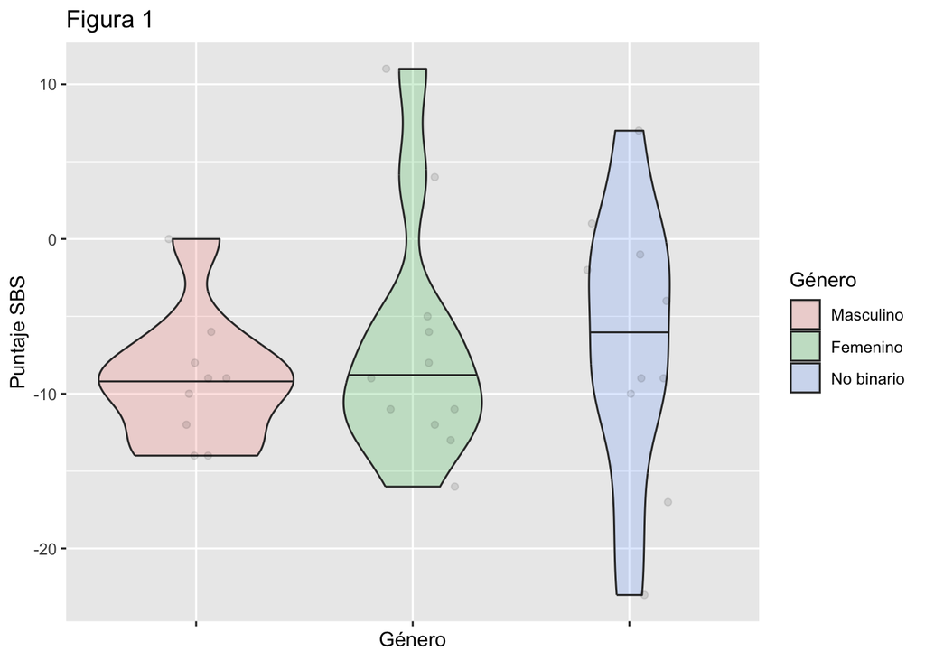

## Análisis

Se construyó un modelo lineal utilizando un único predictor para obtener la Edad a partir del puntaje SBS (ver tabla 2).

Tabla 2

| **Characteristic** | **Beta** | **95% CI** | **p-value** |
| --- | --- | --- | --- |
| (Intercept) | 27 | 22, 31 | <0.001 |
| Puntaje SBS | -0.15 | -0.58, 0.27 | 0.5 |
| No. Obs. | 30 |  |  |
| Residual df | 28 |  |  |
| R² | 0.019 |  |  |
| Adjusted R² | -0.016 |  |  |

Abbreviation: CI = Confidence Interval

## Discusión

El modelo creado se basa en la premisa que el puntaje SBS podría predecir la edad de los participantes.

Considerando lo anterior, el puntaje SBS no fue un buen predictor para la Edad, beta = -0.15 (95% CI -0.58, 0.27; p=0.5)